# A Breif Introduction to Quantum Mechanics

Quantum mechanics studies the smallest parts of our universe. One main difference between the quantum mechanical world, and the world we interact with daily, is that quantum particles behave probabilistically. That is, where a classical object will always follow the same interactions, quantum particles behave differently each time, with their behavior defined by probability density functions. A particles probability density function is given by its *wavefunction*, $\psi(x)$, where $|\psi(x)|^2$ (magnitude squared) is the probability to find that particle at position $x$.

What does it mean to define a particle's position by a continuous function? This is where quantum mechanics requires a new method of thinking. Normally when we think of an object's position, it can be defined in terms of $(x, y, z)$ coordinates, and exists only in that location. Quantum particles, however, somewhat "exist" in *all* locations until measured. Once measured, the continuous wavefunction will collapse into a single point, defining the location of the particle.

For example, if a particle has a wave function defined by a sine function on the interval $[0, \pi]$, the PDF will look like:

[figure not shown]

Notice that the function has some normalization constant out front. This is required as the total probability for existence must be equal to one. Mathematically, the normalization constant can be found by integrating the entire PDF which is equal to one, then solving for the constant; however, that goes slightly beyond the scope of quantum computing basics.

This wavefunction suggests that the *most likely* location to measure our particle is in the middle at $\frac{\pi}{2}$. However, if we were to measure a series of particles that had this wavefunction, not all would be located at $\frac{\pi}{2}$, which is the most important point of this example. The location of particles are probabilistically defined by their wavefunctions, and are unknown until measured. This phenomenon is the beginning of what gives quantum processors their advantages over classical computers and will become more apparent in future sections.

### Dirac Notation

Before continuing into quantum mechanics, it is important to establish a new style for representing linear algebra. Dirac notation, also known as Bra-Ket notation, allows us to easily represent quantum states. Bra-ket notation uses two new vector representations, bras and kets, which are equivalent to row vectors and column vectors, respectively. Bras are represented as $$\langle a |$$ and kets by $$| b \rangle$$

We define general length two bras and kets for example purposes:

$$\langle a | = \begin{pmatrix} a_1 \ a_2 \end{pmatrix}$$

$$| b \rangle = \begin{pmatrix} b_1 \\ b_2 \end{pmatrix}$$

Like normal vectors, bras and kets can be scaled

$$n\langle a | = \begin{pmatrix} na_1 \ na_2 \end{pmatrix}$$

$$n| b \rangle = \begin{pmatrix} nb_1 \\ nb_2 \end{pmatrix}$$

Bras can be added to bras, and kets can be added to kets

$$ | b \rangle + | c \rangle = \begin{pmatrix} b_1 \\ b_2 \end{pmatrix} + \begin{pmatrix} c_1 \\ c_2 \end{pmatrix} = \begin{pmatrix} b_1 + c_1 \\ b_2 + c_2 \end{pmatrix}$$

A bra can be transformed into a ket and vice versa by taking the conjugate transpose, or dagger operator of the state:

$$\langle a |^{*T} = \langle a |^\dagger = \begin{pmatrix} a_1 \ a_2 \end{pmatrix}^\dagger = \begin{pmatrix} a_1^* \\ a_2^* \end{pmatrix} = | a \rangle$$

And a normal linear algebra dot product is represented by

$$\langle a | b \rangle = \begin{pmatrix} a_1 \ a_2 \end{pmatrix} \cdot \begin{pmatrix} b_1 \\ b_2 \end{pmatrix} = a_1b_1 + a_2b_2$$

which is referred to as the *inner product*.

### Basis Vectors and Superposition

Bras and kets are used to define the **basis vectors** which will be incredibly important going forwards. In the Z basis, these are defined as

$$|0\rangle \ = \ \begin{pmatrix} 1 \\ 0 \end{pmatrix} \ \ \ \ \ \ |1\rangle \ = \ \begin{pmatrix} 0 \\ 1 \end{pmatrix}$$

These are the most fundamental vectors for our purposes, as a particle in the $|0\rangle$ state will have an output measurement of 0, and a particle in the state $|1\rangle$ state will have an output measurement of 1, *when taking a z measurement*.

However, and this is where quantum particles differ from classical particle, the particle can exist in a state which will produce difference z measurements. It is possible for a particle to be in a *linear combination* of states. For example, a particle might be in the state $|\psi\rangle = \alpha|0\rangle + \beta|1\rangle$, where $\alpha$ and $\beta$ are constants, with $|\alpha|^2 + |\beta|^2 = 1$, which is our normalization condition. $|\alpha|^2$ and $|\beta|^2$ represent the probability of the z measurement to result in a 0 or 1, respectively. The particle existing in this linear combination of states is referred to as *superposition*.

Let us solve for a state which has equal probabilities for the outcome of a z measurement. In other words,

$$\alpha^2 + \beta^2 = 1$$

$$\alpha^2 = \beta^2$$

$$2\alpha^2 = 1$$

$$\alpha = \frac{1}{\sqrt{2}}$$

$$\implies |\psi\rangle = \frac{1}{\sqrt{2}}(|0\rangle + |1\rangle)$$

In the future we will see that measuring a particle in this state will result in equal measurements of 0 and 1. The state we just produced is considered the **x basis**, with the state symbols given as

$$|+\rangle = \frac{1}{\sqrt{2}}(|0\rangle + |1\rangle)$$

and

$$|-\rangle = \frac{1}{\sqrt{2}}(|0\rangle - |1\rangle)$$

The third basis, which is the **y basis**, is defined with complex numbers, as follows

$$|\circlearrowright\rangle = \frac{ | 0 \rangle + i | 1 \rangle}{\sqrt{2}}$$

$$|\circlearrowleft\rangle = \frac{ | 0 \rangle -i | 1 \rangle}{\sqrt{2}}$$

### Classical Bits versus Quantum Bits (Qubits)

The quantum mechanical particles described above are the base unit of quantum information used in a quantum computer. Where in classical computing the base unit is called a *bit*, in quantum computing they are called quantum bits, or *qubits*. A single qubit can be in the states described above, and it is the physical entity that we manipulate and measure.

A classical bit is straightforward and easy to define. A bit either takes the value of a 0 or a 1. The classical bit is in a single state at any given time, and any measurement will simply result in that state, which is intuitive. As described above, the qubit can be in 0 or 1 like the classical bit, but it can also be in any state between 0 or 1. This is much easier visualized on the **Bloch Sphere**, which is the unit sphere representing the possible linear combinations between the x, y, and z basis. The following figure shows the Block sphere, with a vector representing the $|0\rangle$ state.

[figure not shown]

The $|+\rangle$ state points purely along the x axis, which is halfway between $|0\rangle$ and $|1\rangle$.

[figure not shown]

Along with the three sets of basis vectors, measurements are made for a single base. The default measurement used in Qiskit measures the z component of a state. When a particle is measured once and reveals an outputs state, further measurements on that particle without any other state changes will result in the same output. For example, if the $|+\rangle$ state was measured, and the outcome was 1, performing more measurements would *always* result in 1. However, after measuring in the z base, the particles x and y measurements reset back to 50/50. We will see how to manipulate the qubit to measure in the x and y basis in the future, but it is important to note that the particle can only be in one deterministic state at a time.

### Manipulating Qubits

When qubits are initialized, they are put into the $|0\rangle$ state. In order the change a qubit's state, we use quantum gates. Quantum gates have matrix representations, and typically perform rotations of the vector around the Block sphere. The output state is given from the matrix multiplication of the gate and the input state. We will start with the simplest gates, known as the Paulis: $X, Y$ and $Z$. These gates have the following matrix representations:

$$ X= \begin{pmatrix} 0&1 \\\\ 1&0 \end{pmatrix}\\\\ Y= \begin{pmatrix} 0&-i \\\\ i&0 \end{pmatrix}\\\\ Z= \begin{pmatrix} 1&0 \\\\ 0&-1 \end{pmatrix} $$

We will look at an example of applying the $X$ gate to the $|0\rangle$ state:

$$X |0\rangle = |1\rangle = \begin{pmatrix} 0&1 \\\\ 1&0 \end{pmatrix} \begin{pmatrix} 1 \\ 0 \end{pmatrix} = \begin{pmatrix} 0 \\ 1 \end{pmatrix} = |1\rangle$$

This takes a 0 input state and transforms it to a 1. Other transitions are

$$ Z |+\rangle = |-\rangle, \\\\ Z |-\rangle = |+\rangle. $$

These are just a couple examples of how qubits can be manipulated. The following sections will cover the various gates and their implementation in Qiskit.

### Quantum Circuits

A quantum circuit represents the control flow that happens in a quantum processor, defining the stages that gates are applied and when measurements are taken. The following image is an example of a quantum circuit. Two qubits are represented by $q_0$ and $q_1$. $q_0$, which is initially loaded as state $|0\rangle$, as the Pauli $X$ gate applied. Then between the barriers (which are not physical, just for the output diagram) both qubits are manipulated with another gate (which will be discussed), and finally are measured into control qubits.

[figure not shown]

The Python code for generating a circuit without any gates is as follows:

```python
from qiskit import *
from qiskit.visualization import plot_histogram, plot_bloch_vector
```

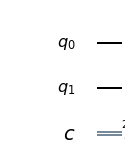

```python
n_q = 2  # number of qubits
n_b = 2  # number of output bits
qc = QuantumCircuit(n_q, n_b)
qc.draw(output='mpl')
```

Adding in some measurement gates

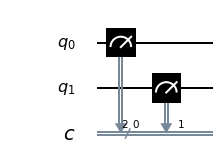

```python
qc.measure(0, 0)
qc.measure(1, 1)
qc.draw(output='mpl')
```

And running the program on a simulator, where we expect to see 0 as the output state for both qubits

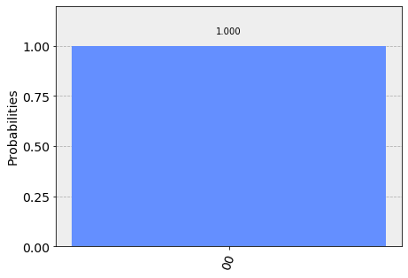

```python
counts = execute(qc, Aer.get_backend('qasm_simulator')).result().get_counts()
plot_histogram(counts)
```

The output is stored as a 2 bit binary string, corresponding to each qubit output state. We see a 100% rate of measure 0 on both qubits because we did nothing with the circuit. If we were to add the Pauli $X$ gate to $q_0$, let's see what happens.

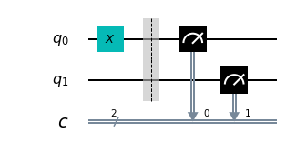

```python
# reinitialize our circuit to add the X gate partway through
qc = QuantumCircuit(n_q, n_b)
qc.x(0)
qc.barrier()
qc.measure(0, 0)
qc.measure(1, 1)
qc.draw(output='mpl')
```

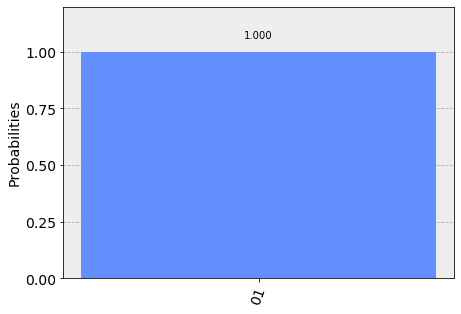

```python
counts = execute(qc, Aer.get_backend('qasm_simulator')).result().get_counts()
plot_histogram(counts)
```

Notice that $q_0$'s output is given by the least significant bit in the output string. We see the flip from 0 to 1, as expected from out matrix derivation. The output probability for this is still 100%, as we have simply put the qubits into the z basis states, which are deterministic upon measuring. We will move onto describing more quantum gates, where the output will become more interesting.

### Single Qubit Gates

The following section will focus on the gates which manipulate a single qubit, along with Qiskit implementations and the Bloch sphere visualization. All code cells require the imports from above.

#### Pauli X

As above, the Pauli X gate is given by

$$X= \begin{pmatrix} 0&1 \\\\ 1&0 \end{pmatrix}\\\\$$

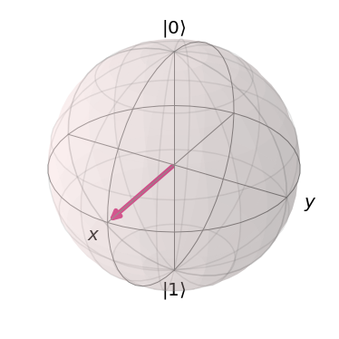

```python
plot_bloch_vector([1, 0, 0])
```

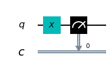

```python
# reinitialize our circuit to add the X gate partway through
qc = QuantumCircuit(1, 1)
qc.x(0)
qc.measure(0, 0)
qc.draw(output='mpl')
```

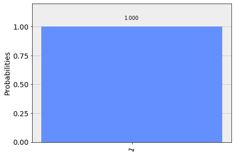

```python
counts = execute(qc, Aer.get_backend('qasm_simulator')).result().get_counts()
plot_histogram(counts)
```

#### Hadamard

The Hadamard gate is highly important as it performs a half rotation about the Bloch sphere, changing the $|0\rangle$ state to the $|+\rangle$ state. This will give us a split probability of measuring 0 or 1, as the qubit has been put into a superposition of states. The Hadamard gate is given by

$$H= \frac{1}{\sqrt{2}}\begin{pmatrix} 1&1 \\\\ 1&-1 \end{pmatrix}\\\\$$

The output will not be perfectly split 50/50 as the simulator runs a finite amount of times, but the results will be close to an even split.

```
qc.h(0) # Hadamard on qubit 0
```

The new state is shown in the Bloch sphere as:

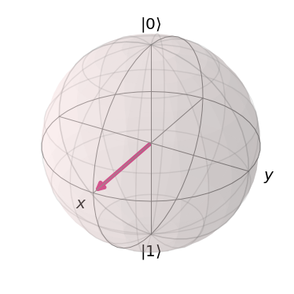

```python
plot_bloch_vector([1, 0, 0])
```

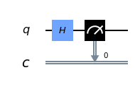

```python
qc = QuantumCircuit(1, 1)
qc.h(0)
qc.measure(0, 0)
qc.draw(output='mpl')
```

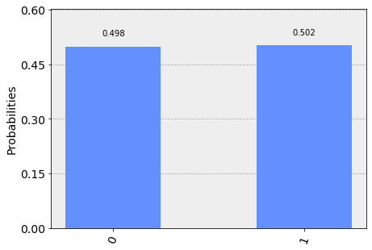

```python
counts = execute(qc, Aer.get_backend('qasm_simulator')).result().get_counts()
plot_histogram(counts)
```

#### S and S Dagger

The S and S$^\dagger$ gates rotate between the x and y basis. Their matrices are given by

$$ S = \begin{pmatrix} 1&0 \\\\ 0&i \end{pmatrix}, \, \, \, \, S^\dagger = \begin{pmatrix} 1&0 \\\\ 0&-i \end{pmatrix}. $$

and their effects are

$$ S |+\rangle = |\circlearrowright\rangle, \, \, \, \, S |-\rangle = |\circlearrowleft\rangle,\\\\ S^\dagger |\circlearrowright\rangle = |+\rangle, \, \, \, \, S^\dagger |\circlearrowleft\rangle = |-\rangle. $$

If applied before a Hadamard gate, this will result in measuring the y component.

```
qc.s(0)   # S on qubit 0
qc.sdg(0) # S† on qubit 0
```

[figure not shown]

```python
qc = QuantumCircuit(1, 1)
qc.sdg(0)
qc.h(0)
qc.measure(0, 0)
qc.draw(output='mpl')
```

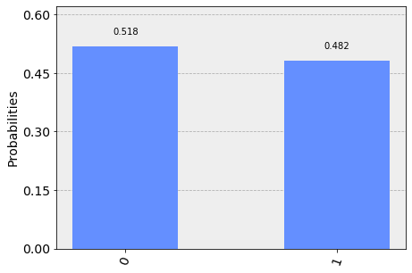

```python
counts = execute(qc, Aer.get_backend('qasm_simulator')).result().get_counts()
plot_histogram(counts)
```

#### Rotation gates

Much like how the Pauli X, Y and Z gates performed rotations about their respective axis, more generalized gates exist which allow rotations at arbitrary angles about their respective axis. These are implemented as the $R_x(\theta)$, $R_y(\theta)$ and $R_z(\theta)$ gates.

$$ R_x(\theta) = \begin{pmatrix} \cos(\frac{\theta}{2})& -i\sin(\frac{\theta}{2}) \\\\ -i\sin(\frac{\theta}{2})&\cos(\frac{\theta}{2}) \end{pmatrix} $$

$$ R_y(\theta) = \begin{pmatrix} \cos(\frac{\theta}{2})& -\sin(\frac{\theta}{2}) \\\\ -\sin(\frac{\theta}{2})&\cos(\frac{\theta}{2}) \end{pmatrix} $$

$$ R_y(\theta) = \begin{pmatrix} e^{\frac{-i\theta}{2}}&0 \\\\ 0&e^{\frac{i\theta}{2}} \end{pmatrix} $$

```
qc.rx(theta, 0) # rx rotation on qubit 0
qc.ry(theta, 0) # ry rotation on qubit 0
qc.rz(theta, 0) # rz rotation on qubit 0
```

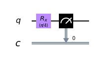

```python
from numpy import pi
theta = pi/4
qc = QuantumCircuit(1, 1)
qc.rx(theta, 0)
qc.measure(0, 0)
qc.draw(output='mpl')
```

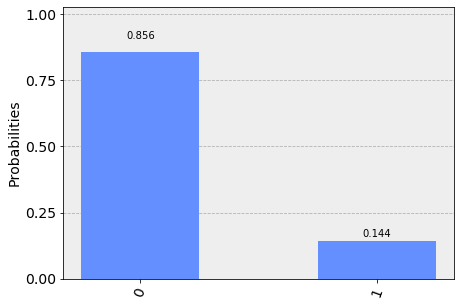

```python
counts = execute(qc, Aer.get_backend('qasm_simulator')).result().get_counts()
plot_histogram(counts)
```

#### T and T Dagger

Two specific angles for the $R_z(\theta)$ gate have their own names. $T$ and $T^\dagger$ are given by angles $\theta=\pm \pi/4$ and have the matrix form

$$ T = \begin{pmatrix} 1&0 \\\\ 0&e^{i\pi/4}\end{pmatrix}, \, \, \, \, T^\dagger = \begin{pmatrix} 1&0 \\\\ 0&e^{-i\pi/4} \end{pmatrix}. $$

```
qc.t(0)   # t on qubit 0
qc.tdg(0) # t† on qubit 0
```

### Multi-Qubit Gates

For quantum computers to compete with their classical counterparts, there must exist gates that facilitate the interaction between multiple qubits. The main ones are the two-qubit controlled-NOT gate (CNOT) and the three-qubit Toffoli.

#### CNOT

The CNOT gate is analogous to the XOR gate. Operating on two qubits, the behavior is as follows:

$$\textbf{CNOT} \ |00\rangle \Rightarrow |00\rangle$$ $$\textbf{CNOT} \ |01\rangle \Rightarrow |01\rangle$$ $$\textbf{CNOT} \ |10\rangle \Rightarrow |11\rangle$$ $$\textbf{CNOT} \ |11\rangle \Rightarrow |10\rangle$$

Using this notation, the first qubit is the control and the second qubit is the output. The second qubit in the output only switches to 1 when one of the first qubits is a 1. We can also define controlled Y and Z gates.

```
qx.cx(0, 1)  # CNOT with control qubit 0, target qubit 1
qc.cy(0,1)   # controlled-Y, control qubit 0, target qubit 1
qc.cz(0,1)   # controlled-Z, control qubit 0, target qubit 1
```

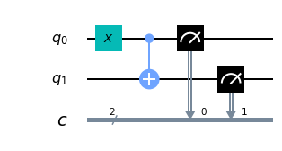

```python
qc = QuantumCircuit(2, 2)
qc.x(0)
qc.cx(0,1)
qc.measure(0,0)
qc.measure(1,1)
qc.draw(output='mpl')
```

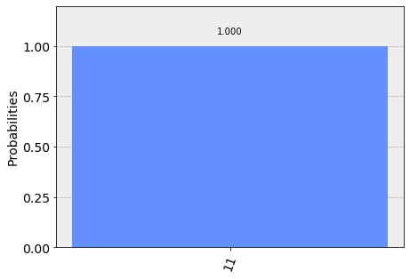

```python
counts = execute(qc, Aer.get_backend('qasm_simulator')).result().get_counts()
plot_histogram(counts)
```

#### Toffoli

```
qc.ccx(0,1,2) # Toffoli controlled on qubits 0 and 1 with qubit 2 as target
```

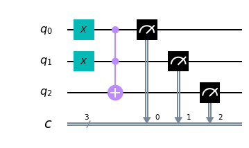

```python
qc = QuantumCircuit(3, 3)
qc.x([0, 1])
qc.ccx(0, 1, 2)
qc.measure(0, 0)
qc.measure(1, 1)
qc.measure(2, 2)
qc.draw(output='mpl')
```

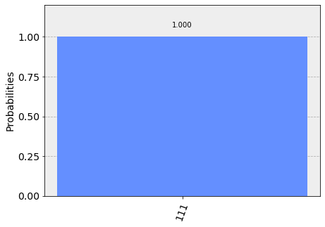

```python
counts = execute(qc, Aer.get_backend('qasm_simulator')).result().get_counts()
plot_histogram(counts)
```

#### Swap

The swap gate causes the two qubits to trade states.

```
qc.swap(0, 1)  # swap qubit 0 and 1's states
```

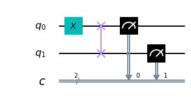

```python
qc = QuantumCircuit(2, 2)
qc.x(0)
qc.swap(0, 1)
qc.measure(0, 0)
qc.measure(1, 1)
qc.draw(output='mpl')
```

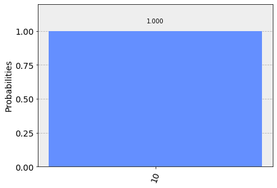

```python
counts = execute(qc, Aer.get_backend('qasm_simulator')).result().get_counts()
plot_histogram(counts)
```